# Three Tables of Genomics & Exploratory Data Analysis

These notes come from Coursera’s Statistics for Genomic Data Science course. Three tables in genomics: Genomics Data, feature data and phenotype data. Next, some exploratory data analysis will be conducted.

#Three Tables in Genomics

```r
#Install Biobase package
if (!require("BiocManager", quietly = TRUE))
    install.packages("BiocManager")

BiocManager::install("Biobase")
```

```r
library(Biobase)
```

Open the connection from bowtie experiment data (recount data) using a URL

```r
connection=url("http://bowtie-bio.sourceforge.net/recount/ExpressionSets/bodymap_eset.RData")
load(file=connection)
ls()
```

```
[1] "bm"           "bodymap.eset" "connection"
```

```r
close(connection)
```

```r
bm=bodymap.eset
bm
```

```
ExpressionSet (storageMode: lockedEnvironment)
assayData: 52580 features, 19 samples
  element names: exprs
protocolData: none
phenoData
  sampleNames: ERS025098 ERS025092 ... ERS025091 (19 total)
  varLabels: sample.id num.tech.reps ... race (6 total)
  varMetadata: labelDescription
featureData
  featureNames: ENSG00000000003 ENSG00000000005 ... LRG_99 (52580
    total)
  fvarLabels: gene
  fvarMetadata: labelDescription
experimentData: use 'experimentData(object)'
Annotation:
```

```r
exp_data=exprs(bm) #Get expression data
dim(exp_data)
```

```
[1] 52580    19
```

```r
head(exp_data)
```

```
                ERS025098 ERS025092 ERS025085 ERS025088 ERS025089
ENSG00000000003      1354       216       215       924       725
ENSG00000000005       712       134         4      1495       119
ENSG00000000419       450       547       516       529       808
ENSG00000000457       188       368       196       386       156
ENSG00000000460        66        29         1        26        11
ENSG00000000938       104        79         7        29         0
                ERS025082 ERS025081 ERS025096 ERS025099 ERS025086
ENSG00000000003       125       796      1954       815       249
ENSG00000000005        20         7         0         0        16
ENSG00000000419       680       744       369       636       486
ENSG00000000457       259       436       288       187       553
ENSG00000000460         9        25        42        12        22
ENSG00000000938         3         1        20       243        41
                ERS025084 ERS025087 ERS025093 ERS025083 ERS025095
ENSG00000000003      4614      6548      5030      1450       781
ENSG00000000005       975       923       696        15        24
ENSG00000000419      1200      2823      2159       933       870
ENSG00000000457      1543      1194       876       655       862
ENSG00000000460       213        80        57        13        78
ENSG00000000938       166       265       211        10        11
                ERS025097 ERS025094 ERS025090 ERS025091
ENSG00000000003        69      1888       983         3
ENSG00000000005         0        20         4         0
ENSG00000000419       621      1026      1185       765
ENSG00000000457       242       569       609       782
ENSG00000000460        17       351        46        73
ENSG00000000938         0         0        22      1508
```

Number of rows in pheno_data should be the same as the number of columns as expression data since each row in pheno data describes each of the columns in expression data.

```r
pheno_data= pData(bm)#Wht are samples made up of, how are they collectd,etc
dim(pheno_data)
```

```
[1] 19  6
```

```r
head(pheno_data)
```

|  | sample.id | num.tech.reps | tissue.type | gender | age | race |
| --- | --- | --- | --- | --- | --- | --- |
| ERS025098 | ERS025098 | 2 | adipose | F | 73 | caucasian |
| ERS025092 | ERS025092 | 2 | adrenal | M | 60 | caucasian |
| ERS025085 | ERS025085 | 2 | brain | F | 77 | caucasian |
| ERS025088 | ERS025088 | 2 | breast | F | 29 | caucasian |
| ERS025089 | ERS025089 | 2 | colon | F | 68 | caucasian |
| ERS025082 | ERS025082 | 2 | heart | M | 77 | caucasian |

Feature data describes genomic features of dataset

```r
feature_data=fData(bm)
dim(feature_data)
```

```
[1] 52580     1
```

```r
head(feature_data)
```

|  | gene |
| --- | --- |
| ENSG00000000003 | ENSG00000000003 |
| ENSG00000000005 | ENSG00000000005 |
| ENSG00000000419 | ENSG00000000419 |
| ENSG00000000457 | ENSG00000000457 |
| ENSG00000000460 | ENSG00000000460 |
| ENSG00000000938 | ENSG00000000938 |

### Exploratory Data Analysis

Install and load necessary packages:

```r
install.packages('gplots')
```

```r
update.packages(repos='http://cran.rstudio.com/', ask=FALSE, checkBuilt=TRUE)
```

```r
install.packages("devtools")
```

[output not shown]

[output not shown]

[output not shown]

[output not shown]

```r
devtools::install_github('alyssafrazee/RSkittleBrewer')
```

```
Error in loadNamespace(x) : there is no package called ‘devtools’
```

```r
if (!require("BiocManager", quietly = TRUE))
    install.packages("BiocManager")

BiocManager::install("org.Hs.eg.db")
```

```r
if (!require("BiocManager", quietly = TRUE))
    install.packages("BiocManager")

BiocManager::install("AnnotationDbi")
```

```r
BiocManager::install("DBI")
```

```r
BiocManager::install("AnnotationDbi")
```

```r
BiocManager::install("org.Hs.eg.db")
```

```r
install.packages("org.Hs.eg.db")
```

```r
library("devtools")
```

```
Error in library("devtools") : there is no package called ‘devtools’
```

```r
library("gplots")
```

```r
library("RSkittleBrewer")
```

```
Error in library("RSkittleBrewer") :
  there is no package called ‘RSkittleBrewer’
```

```r
library("org.Hs.eg.db")
```

```r
library("AnnotationDbi")
```

Set the palette with defined colors.

```r
girly_colors=c('orchid3','magenta3','turquoise2','slateblue2','palegreen1')
palette(girly_colors)
```

Make sure circles are filled in when making plots.

```r
par(pch=19)
```

Check tables available

```r
ls()
```

```
[1] "bm"           "bodymap.eset" "connection"   "exp_data"
[5] "feature_data" "girly_colors" "pheno_data"
```

```r
head(pheno_data)
```

|  | sample.id | num.tech.reps | tissue.type | gender | age | race |
| --- | --- | --- | --- | --- | --- | --- |
| ERS025098 | ERS025098 | 2 | adipose | F | 73 | caucasian |
| ERS025092 | ERS025092 | 2 | adrenal | M | 60 | caucasian |
| ERS025085 | ERS025085 | 2 | brain | F | 77 | caucasian |
| ERS025088 | ERS025088 | 2 | breast | F | 29 | caucasian |
| ERS025089 | ERS025089 | 2 | colon | F | 68 | caucasian |
| ERS025082 | ERS025082 | 2 | heart | M | 77 | caucasian |

### Explore the pheno_data table

```r
table(pheno_data$gender)
```

```
F M
8 8
```

```r
table(pheno_data$gender, pheno_data$race)
```

```
    african_american caucasian
  F                1         7
  M                0         8
```

```r
summary(exp_data)
```

```
   ERS025098           ERS025092          ERS025085
 Min.   :      0.0   Min.   :     0.0   Min.   :     0.0
 1st Qu.:      0.0   1st Qu.:     0.0   1st Qu.:     0.0
 Median :      0.0   Median :     0.0   Median :     0.0
 Mean   :    455.6   Mean   :   361.1   Mean   :   399.3
 3rd Qu.:      0.0   3rd Qu.:     0.0   3rd Qu.:     0.0
 Max.   :1584528.0   Max.   :499802.0   Max.   :808641.0
   ERS025088           ERS025089         ERS025082
 Min.   :      0.0   Min.   :      0   Min.   :      0
 1st Qu.:      0.0   1st Qu.:      0   1st Qu.:      0
 Median :      0.0   Median :      0   Median :      0
 Mean   :    445.5   Mean   :    445   Mean   :    509
 3rd Qu.:      0.0   3rd Qu.:      0   3rd Qu.:      0
 Max.   :1014579.0   Max.   :1415741   Max.   :2484692
   ERS025081           ERS025096         ERS025099
 Min.   :      0.0   Min.   :      0   Min.   :     0.0
 1st Qu.:      0.0   1st Qu.:      0   1st Qu.:     0.0
 Median :      0.0   Median :      0   Median :     0.0
 Mean   :    430.4   Mean   :    558   Mean   :   445.5
 3rd Qu.:      0.0   3rd Qu.:      0   3rd Qu.:     0.0
 Max.   :1356643.0   Max.   :3517964   Max.   :572374.0
   ERS025086          ERS025084          ERS025087
 Min.   :     0.0   Min.   :     0.0   Min.   :     0
 1st Qu.:     0.0   1st Qu.:     0.0   1st Qu.:     0
 Median :     0.0   Median :     0.0   Median :     0
 Mean   :   370.7   Mean   :   592.1   Mean   :  1097
 3rd Qu.:     0.0   3rd Qu.:     0.0   3rd Qu.:     0
 Max.   :458168.0   Max.   :287539.0   Max.   :519683
   ERS025093           ERS025083          ERS025095
 Min.   :      0.0   Min.   :     0.0   Min.   :      0.0
 1st Qu.:      0.0   1st Qu.:     0.0   1st Qu.:      0.0
 Median :      0.0   Median :     0.0   Median :      0.0
 Mean   :    997.7   Mean   :   434.7   Mean   :    479.6
 3rd Qu.:      0.0   3rd Qu.:     0.0   3rd Qu.:      0.0
 Max.   :1332827.0   Max.   :626824.0   Max.   :1605570.0
   ERS025097           ERS025094          ERS025090
 Min.   :      0.0   Min.   :     0.0   Min.   :     0.0
 1st Qu.:      0.0   1st Qu.:     0.0   1st Qu.:     0.0
 Median :      0.0   Median :     0.0   Median :     0.0
 Mean   :    540.1   Mean   :   518.5   Mean   :   465.3
 3rd Qu.:      0.0   3rd Qu.:     0.0   3rd Qu.:     0.0
 Max.   :1888083.0   Max.   :776623.0   Max.   :535410.0
   ERS025091
 Min.   :      0.0
 1st Qu.:      0.0
 Median :      0.0
 Mean   :    530.1
 3rd Qu.:      0.0
 Max.   :1221921.0
```

```r
table(pheno_data$age)
```

```
19 29 37 47 58 60 65 68 73 77 86
 1  1  1  1  1  3  1  1  2  3  1
```

To see NA values in the table:

```r
table(pheno_data$age, useNA='ifany')
```

```
  19   29   37   47   58   60   65   68   73   77   86 <NA>
   1    1    1    1    1    3    1    1    2    3    1    3
```

Check if there are ay common missing value

```r
sum(pheno_data$age==" ", na.rm=TRUE)
```

```
[1] 0
```

Check to see if there are any missing values in the genomic data. Here wecheck row by row.

```r
is.na(exp_data)[1,]
```

```
ERS025098 ERS025092 ERS025085 ERS025088 ERS025089 ERS025082 ERS025081
    FALSE     FALSE     FALSE     FALSE     FALSE     FALSE     FALSE
ERS025096 ERS025099 ERS025086 ERS025084 ERS025087 ERS025093 ERS025083
    FALSE     FALSE     FALSE     FALSE     FALSE     FALSE     FALSE
ERS025095 ERS025097 ERS025094 ERS025090 ERS025091
    FALSE     FALSE     FALSE     FALSE     FALSE
```

An alternativeis to sum the rows that have missing values and check for non-zero values:

```r
gene_na=rowSums(is.na(exp_data))
table(gene_na)
```

```
gene_na
    0
52580
```

Check column by column alternatively:

```r
gene_na=colSums(is.na(exp_data))
table(gene_na)
```

```
gene_na
 0
19
```

### Plotting and Exploratory Data Analysis

```r
dim(exp_data)
```

```
[1] 52580    19
```

```r
head(exp_data)
```

```
                ERS025098 ERS025092 ERS025085 ERS025088 ERS025089
ENSG00000000003      1354       216       215       924       725
ENSG00000000005       712       134         4      1495       119
ENSG00000000419       450       547       516       529       808
ENSG00000000457       188       368       196       386       156
ENSG00000000460        66        29         1        26        11
ENSG00000000938       104        79         7        29         0
                ERS025082 ERS025081 ERS025096 ERS025099 ERS025086
ENSG00000000003       125       796      1954       815       249
ENSG00000000005        20         7         0         0        16
ENSG00000000419       680       744       369       636       486
ENSG00000000457       259       436       288       187       553
ENSG00000000460         9        25        42        12        22
ENSG00000000938         3         1        20       243        41
                ERS025084 ERS025087 ERS025093 ERS025083 ERS025095
ENSG00000000003      4614      6548      5030      1450       781
ENSG00000000005       975       923       696        15        24
ENSG00000000419      1200      2823      2159       933       870
ENSG00000000457      1543      1194       876       655       862
ENSG00000000460       213        80        57        13        78
ENSG00000000938       166       265       211        10        11
                ERS025097 ERS025094 ERS025090 ERS025091
ENSG00000000003        69      1888       983         3
ENSG00000000005         0        20         4         0
ENSG00000000419       621      1026      1185       765
ENSG00000000457       242       569       609       782
ENSG00000000460        17       351        46        73
ENSG00000000938         0         0        22      1508
```

Here we see that most values for each of the samples are very close to zero. Next, we can log transform the data.

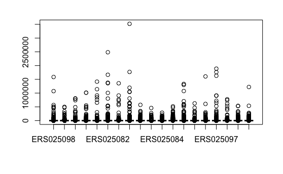

```r
boxplot(exp_data[,1:19])
```

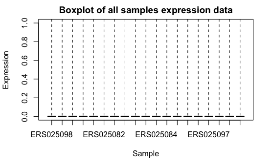

```r
boxplot(log2(exp_data+1),
        col=1,
        range=0,
        ylim=c(0,1)
        ,xlab="Sample",
        ylab="Expression",
        main="Boxplot of all samples expression data", font.main=1)
```

Make histogram. For this example, The histogram below represents the sample representedon coumn 1 of exp_data.

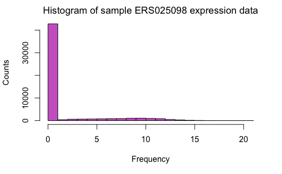

```r
par(mfrow=c(1,1))
hist(log2(exp_data[,1]+1),col=1,main="Histogram of sample ERS025098 expression data",
        xlab="Frequency",
        ylab="Counts", font.main=1)
```

Density plots. We can ad plots on top of eachoter. Example with the first three samples:

```r
plot(density(log2(exp_data[,1]+1)),col=3, main="Density plots of first three samples")
lines(density(log2(exp_data[,2]+1)),col=1)
```

[figure not shown]

```r
lines(density(log2(exp_data[,3]+1)),col=4)
```

qqplots. Each dot represents one quantile in each distribution. You can compare the percentiles sample by sample. Drawing 45 degree line helps to see the difference between the two samples.

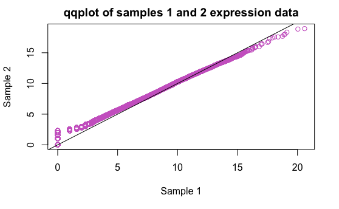

```r
qqplot(log2(exp_data[,1]+1),log2(exp_data[,2]+1), col=1, main="qqplot of samples 1 and 2 expression data",xlab="Sample 1",
     ylab="Sample 2")
abline(c(0,1))
```

Bland Altman Plot (MA Plot). This is done by taking the difference between the two samples as the y axis and the sum of the two samples as the x axis (both log transformed). In this plot we can see that as the counts increase the samples get closed together in similarity.

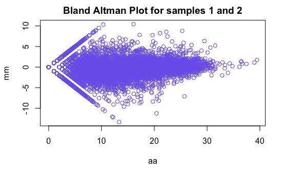

```r
mm=log2(exp_data[,1]+1)-log2(exp_data[,2]+1)
aa=log2(exp_data[,1]+1)+log2(exp_data[,2]+1)
plot(aa, mm, col=4, main="Bland Altman Plot for samples 1 and 2")
```

For count based data,it is helpful to remove low-count features. Create a dataframe in order to be able to use the dplyr filtering commands to remove means less than one.

```r
install.packages('dplyr')
library('dplyr')
```

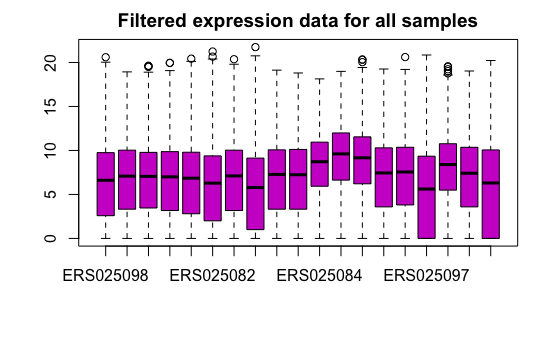

```r
exp_data=as.data.frame(exp_data)
filtered_edata=dplyr::filter(exp_data,rowMeans(exp_data)>1)
boxplot(as.matrix(log2(filtered_edata+1)),col=2, main="Filtered expression data for all samples")
```

### Compare dataset to annotation and metadat

Get the IDs for the features.

```r
ls()
```

```
 [1] "aa"             "bm"             "bodymap.eset"   "connection"
 [5] "exp_data"       "feature_data"   "filt_edata"     "filtered_edata"
 [9] "gene_na"        "girly_colors"   "mm"             "pheno_data"
```

```r
head(pheno_data)
```

|  | sample.id | num.tech.reps | tissue.type | gender | age | race |
| --- | --- | --- | --- | --- | --- | --- |
| ERS025098 | ERS025098 | 2 | adipose | F | 73 | caucasian |
| ERS025092 | ERS025092 | 2 | adrenal | M | 60 | caucasian |
| ERS025085 | ERS025085 | 2 | brain | F | 77 | caucasian |
| ERS025088 | ERS025088 | 2 | breast | F | 29 | caucasian |
| ERS025089 | ERS025089 | 2 | colon | F | 68 | caucasian |
| ERS025082 | ERS025082 | 2 | heart | M | 77 | caucasian |

```r
IDS<-as.character(rownames(exp_data))
head(IDS)
```

```
[1] "ENSG00000000003" "ENSG00000000005" "ENSG00000000419"
[4] "ENSG00000000457" "ENSG00000000460" "ENSG00000000938"
```

Get the chromosome information for each of the ensemble IDs

```r
chr=AnnotationDbi::select(org.Hs.eg.db, keys=IDS,keytype="ENSEMBL",columns="CHR")
```

```r
head(chr)
```

|  | ENSEMBL | CHR |
| --- | --- | --- |
| 1 | ENSG00000000003 | X |
| 2 | ENSG00000000005 | X |
| 3 | ENSG00000000419 | 20 |
| 4 | ENSG00000000457 | 1 |
| 5 | ENSG00000000460 | 1 |
| 6 | ENSG00000000938 | 1 |

Check that chr has the same dimensions as the expression dataset-it doesnt. Remove duplicated values from chromosome dataset.

```r
dim(chr)
```

```
[1] 52624     2
```

```r
dim(exp_data)
```

```
[1] 52580    19
```

```r
chr=chr[!duplicated(chr[,1]),]
dim(chr)
```

```
[1] 52580     2
```

Check that all of the row names in the chromosome data match with the rownames in the expression data.

```r
all(chr[,1]==rownames(exp_data))
```

```
[1] TRUE
```

Filter chromosome Y samples. Convert exp_data to dataframe to apply the filter command.